# Function Documentation

Elizabeth Purdom

2016-03-12

The goal of this package is to allow the user to try many different clustering algorithms in one package structure. In particular, the package encodes many common practices that are shared across clustering algorithms, like subsampling the data, not clustering samples with negative silhouete scores, sequentially removing clusters and reclustering, and so forth, and allows the user to simply make different choices the parameters as well as the underlying clustering algorithm. The package also allows the user to define their own clustering algorithm.

There are two main user-functions, `clusterSingle` and `clusterMany`. `clusterSingle` is the wrapper function that calls the underlying functions and `clusterMany` runs `clusterSingle` across combinations of parameter choices. Another useful function is `subsampleClustering` which does subsampling of the data and returns a $nxn$ matrix $D$ of the proportion of co-occurances of samples in the same cluster.

There are three main choices that the user needs to make for `clusterSingle`:

- What clustering algorithm to use (`clusterFunction`).
- Whether to cluster the co-occurence matrix created by clustering subsampled data (`subsample=TRUE`). Otherwise `dist(x)` is clustered (`subsample=FALSE`).
- Whether to run a sequential strategy (`sequential=TRUE`) which finds the best cluster, removes those samples, and then starts the clustering again.

The `clusterSingle` calls underlying functions for each of these tasks, each of which can take many arguments. For simplicity in syntax, the user passes arguments to each of these underlying functions as lists of arguments.

For this reason, the next sections will go through the functions that form the components of `clusterSingle` so as to better explain the possible options that can be passed.

# Basic Clustering Sequence

First we will discuss if `sequential=FALSE`, i.e. the user does not choose to use the sequential removal of clusters. Then the algorithm performs what we call the “basic clustering sequence” (this basic sequence is also called iteratively by the sequential method).

There are two parts to the basic clustering sequence:

- (Optional, if `subsample=TRUE`) Subsample data and cluster it repeatedly via the function `subsampleClustering`. The arguments passed to `subsampleClustering` are via `subsampleArgs` in `clusterSingle`. The most important arguments that a user may need to pass to `subsampleCluster` are:
- `x` the $n\times p$ data matrix (which is handled by the argument `x` to `clusterSingle` so the user does not need to set it)
- `k` the number of clusters to fit in the subsampled data. This must be passed by the user via `subsampleArgs` (unless `sequential=TRUE`, see below, where it is set internally)
- `clusterFunction` the function to use to cluster the subsampled data. The default is `pam` from the `cluster` package but can also be user-defined. The argument `clusterFunction` of `clusterSingle` is *not* passed to this argument – `clusterSingle` by default uses the `pam` function – so the user must pass this *via `subsampleArgs`* if they want a different function.
- Clustering an input $D$ matrix `clusterD`, which can be either the co-occurance matrix from `subsampleClustering` or otherwise is calculated as `dist(x)`. The arguments passed to `clusterD` are via the argument `mainClusterArgs` in `clusterSingle`. The most important arguments are:
- `D` the $n\times n$ matrix of dissimilarities
- `clusterFunction` the type of clustering to do on the dissimilarity matrix.
- Note that both of the above options are direct arguments of `clusterSingle` (i.e. do not need to be passed with a list of arguments for). Therefore `clusterFunction` argument of `clusterSingle` is passed to `clusterD` (and not to `subsampleClustering`)
- Depending on the choice of `clusterFunction` some other arguments may be necessary to pass via a list of arguments to `mainClusterArgs` (e.g. if “pam”, must also pass an argument `k` or `findBestK=TRUE`)

We will load some simulated data that comes with the package with four underlying clusters. First we will do just basic clustering of the data for 4 clusters using `pam` on the standard distance matrix.

```r
library(clusterExperiment)
data(simData)
simpleCluster<-clusterSingle(simData, subsample=FALSE,
                          sequential=FALSE, clusterFunction="pam",mainClusterArgs=list('k'=4))
#compare to direct call of pam
library(cluster)
pamCluster<-pam(dist(simData),4)
table(pamCluster$clustering,simpleCluster$clustering)
```

```
##
##       1   2   3   4
##   1 100   0   0   0
##   2   0   0   0  48
##   3   0   0  52   0
##   4   0 100   0   0
```

Of course, this is not the best use case, since the pam object from `pam` has much more information. Let’s instead choose to do subsampling, and then cluster the co-occurance matrix.

```r
#library(clusterPackage)
subsampleCluster<-clusterSingle(simData, subsample=TRUE,
                             sequential=FALSE, clusterFunction="pam",mainClusterArgs=list('k'=4))
```

```
## Warning in clusterSingle(simData, subsample = TRUE, sequential = FALSE,
## clusterFunction = "pam", : did not give 'k' in 'subsampleArgs'. Set to 'k'
## argument in 'mainClusterArgs'
```

```r
table(pamCluster$clustering,subsampleCluster$clustering)
```

```
##
##      1  2  3  4
##   1  1 99  0  0
##   2 48  0  0  0
##   3 52  0  0  0
##   4 97  1  1  1
```

Notice that we got a warning. This is because we *could* have chosen to cluster with a different number of clusters on the subsampled data than we clustered the co-occurance data. Similarly, the ‘clusterFunction’ argument is passed to `clusterD` – i.e. the clustering that is done on the co-occurance matrix. We could use something different for clustering of the subsampled data. For example, the following clusters the subsampled data with k=2 and use kmeans, but then clusters the co-occurance matrix with k=4 and pam.

```r
subsampleCluster2<-clusterSingle(simData, subsample=TRUE, sequential=FALSE,
                              clusterFunction="pam",mainClusterArgs=list('k'=4),
                              subsampleArgs=list("k"=2, clusterFunction="kmeans"))
table(subsampleCluster2$clustering,subsampleCluster$clustering)
```

```
##
##      1  2  3  4
##   1 99 98  1  0
##   2 99  0  0  1
##   3  0  1  0  0
##   4  0  1  0  0
```

If we want to see the co-occurance matrix, rather than just cluster it, we need to call `subsampleClustering` directly, in which case we can plot it and visualize the results.

```r
subD<-subsampleClustering(simData, clusterFunction="pam",k=2)
require(NMF)
```

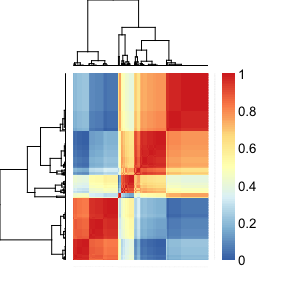

```r
aheatmap(subD)
```

## `clusterSingle` Diagram

The following image shows how these clustering functions are put together by `clusterSingle` to form the basic clustering sequence, where the functions are indicated by ovals in the flowchart.

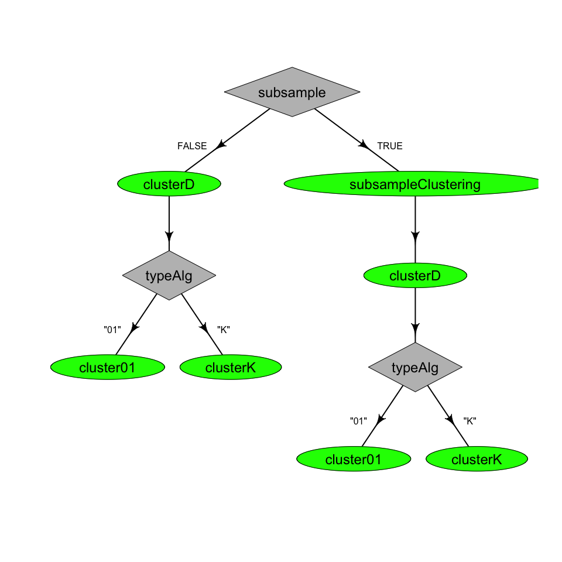

We will go through each of these functions in what follows.

## Subsampling and Clustering subsampled data.

The subsampling of the data and clustering of resampled data is done by the function `subsampleClustering`. It takes as input a $n\times p$ data matrix, with samples on the rows. It subsamples the samples (i.e. rows) so that `samp.p` proportion of the samples are in each subsample. The subsample is then clustered (based on the `clusterFunction` argument). `clusterFunction` can be a user-specified function, but can also take on character values to indicate that the function should use the built-in clustering functions (currently ‘kmeans’ and ‘pam’).

This subsampling and clustering is done `resamp.num` times. The end results is a $n\times n$ co-occurance matrix of the proportion of times that each sample was in the same cluster (out of those subsamples where both samples were chosen).

The function also allows for co-occurance to be based not on just those samples that subsample together, but on all samples by assigning the non-subsampled samples to a cluster by setting the option `classifyMethod="All"`. In this case, the co-occurance calculation is based not directly on the clustering of the subsampled data, but the *assignment* of all samples to clusters, which is done via the `classifyFunction` function (again either user-defined, or set automatically when the user choosing ‘kmeans’ or ‘pam’ for the `clusterFunction` option). Similarly the user can choose `classifyMethod="OutOfSample"` to indicate that co-occurance should be based only on when two samples are both *not* included in a subsample (in which case the samples are assigned to a cluster via `classifyFunction`, as described above).

## Clustering

`clusterD` is the basic function that clusters an input $n x n$ dissimilarity matrix $D$ based on the `clusterFunction` option given by the user (which can be either a character string of pre-detemined options or a user-defined functions). There are (currently) two flavors of `clusterD` supported, depending on the nature of the dissimilarity matrix $D$ – meaning that `clusterD` calls one of two different functions (`cluster01` and `clusterK`) to do the clustering. If the user chooses one of the default clustering methods by setting `clusterFunction` to be a character value (one of “pam”,“tight”,or “hierarchical”) then `clusterD` automatically recognizes what kind of clustering algorithm (‘01’ or ‘K’) is being used and calls it.

However, if the user defines a clustering algorithm in their input to `clusterFunction`, then the user must also give the argument `typeAlg` to indicate what type of clustering function they are provided. This is because the output of ‘01’ and ‘K’ clusterings are treated differently by the function.

Each type of clustering algorithm has minimal requirements for the arguments to `clusterFunction` (described below). Additional arguments can be passed via the `clusterArgs` function, as in `subsampleClustering`.

### cluster01

`cluster01` is intended for clustering algorithms that assume the elements of the input matrix $D$ are in $[0,1]$ and use the value of the elements of $D$ to determine the clusters (i.e. the clustering algorithm doesn’t require an input $K$ to define the number of clusters). The intended use-case here is when $D$ is based on subsampling the samples and clustering them and so that $D$ is a co-occurence matrix.

If the `clusterFunction` is of type `01`, then the following additional arguments can be passed to `clusterD`: `alpha`. `alpha` is a required parameter for `01` arguments and is by default set to 0.01.

Built-in clustering functions for ‘01’ type algorithms for include ‘tight’ and ‘hierarchical’, both of which search for indices of samples $\mathcal{I}$ of samples for which the submatrix $D[\mathcal{I},\mathcal{I}]$ has values close to $1$ in order to determine a cluster. In this way, instead of requiring the number of clusters, there is a tuning parameter $\alpha\in(0,1)$ which determines if the $D[\mathcal{I},\mathcal{I}]$ values are sufficiently close to $1$.

`clusterFunction` should be a function that takes (as a minimum) an argument `D` and `alpha`. Additional arguments can be present and passed to `clusterFunction` via the `clusterArgs` option of `clusterD`. The output of `clusterFunction` must be a list with each element of the list corresponding to a cluster, and the elements of the list containing the indices of the samples that are in the cluster. The list is expected to be in order of ‘best clusters’ (as defined by the `clusterFunction`), with first being the best and last being worst.

**Built-in 01 Methods**: Setting `clusterFunction="tight"` refers to the method of finding clusters from a subsampling matrix given in the tight algorithm of Tsang and Wong. The code is copied from the `tight.clust` package (note that the description in the paper is vague, see code to see how it works). The function starts by finding a core cluster of samples which have similarity 1, and then adding samples to that core cluster that all have similarity greater than or equal to 1-`alpha`. Arguments for the tight method are `minSize.core` (default=2), which sets the minimimum number of samples that form a `core` cluster – i.e. how many samples must have similarity exactly 1 to start building a cluster.

Setting `clusterFunction="hierarchical"` refers to running the `hclust` algorithm on `D` and transversing down the hierarchical tree until getting a block of samples $\mathcal{I}$ such that $f(D[\mathcal{I},\mathcal{I}])$ is greater than or equal to 1-`alpha`. Arguments that can be passed to ‘hierarchical’ are `evalClusterMethod` which determines the function $f$ – i.e. how to summarize the values of $D[\mathcal{I},\mathcal{I}]$ in order to determine if the block of samples is sufficiently similar. If `evalClusterMethod="minimum"` (default) takes as $f$ simply the minimum of $D[\mathcal{I},\mathcal{I}]$ and requires it to be greater than or equal to 1-alpha to be a cluster. `evalClusterMethod="average"` takes $f$ to be the minimum of the row means of $D[\mathcal{I},\mathcal{I}]$. Arguments to `hclust` can also be passed via `clusterArgs` to control the hierarchical clustering of `D`.

### clusterK

`clusterK` is intended for algorithms that expect the user to give a value $K$ giving the number of clusters. This function then includes options appropriate for such algorithms, such as searching over a range of values $K$ and returning the ‘best’ cluster, or removing samples with low ‘silhouette’ values.

If the `clusterFunction` is of type `K`, then additional arguments can be passed to `clusterD`: `k`,`findBestK`, `removeSil`,`kRange`,`silCutoff` (see below for description)

For `clusterK` functions, `clusterFunction` should be a function that takes as a minimum an argument ‘D’ and ‘k’. The output must be a list similar to that of `partition.object` of `cluster` package. Specifically, an element `clustering` which gives the vector of clusters; and an argument `silinfo` like that of the `partition.object` – that is a list with silhouette values.

Whether these silhouette values are actually silhouette values is up to the `clusterFunction`, but they will be used in the following way. If `findBestK=TRUE`, silinfo$avg.width will be used to pick the best $K$ and the set of values of $K$ that will be searched over is given by `kRange`. If `removeSil=TRUE`, then `silinfo$widths[,"sil_width"]` will be used to exclude samples whose value of `silinfo$widths[,"sil_width"]` is less than `silCutoff`. In addition, clusters will be ordered by the average of the values `silinfo$widths[,"sil_width"]` in each cluster (after removing poorly clustered samples, if `removeSil=TRUE`).

**Built-in clusterK methods**: `clusterFunction="pam"` performs `pam` clustering on the input `D` using `pam` in the `cluster` package. Arguments to `pam` can be passed via `clusterArgs`, except for the arguments `x` and `k` which are given by `D` and `k` directly in the call to `clusterD`.

# Sequential option

The `clusterSingle` function also provides the ability to do sequential clustering, namely clustering the data, removing the cluster, and reclustering the remaining data. Since clustering algorithms can be sensitive to what set of samples are being used, this can have an impact on the clustering results. Furthermore, it can avoid the question of setting the number of clusters k, and instead find the number of clusters as when the sequential strategy doesn’t find any more clusters (or enough samples) to cluster. Of course the stopping rules themselves requires tuning parameters, so is only a gain if the stopping rules are more intuitive or defensible than picking the number of clusters.

Once such a cluster is found, the samples in the cluster are removed, and the process of finding another stable is restarted.

## Sequential Clustering Diagram

The following image represents how the sequential strategy works:

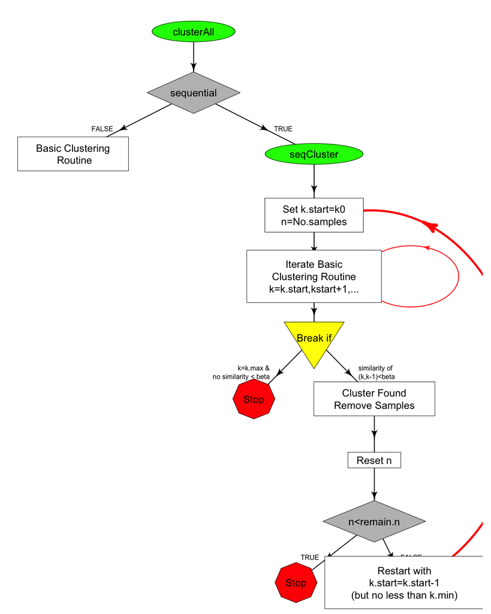

# Compare many parameters (`clusterMany`)

`clusterMany` is a function for running many different combinations of parameters or different datasets. It’s main goal is to make it easy to running many different parameter choices and reduce the coding overhead for doing so. `clusterMany` calls `clusterSingle` using `lapply` (or `mclapply` if parallelizing the computation). Example uses of `clusterMany` would be to run the same clustering over data sets representing different number of dimensions in a PCA dimensionality reduction, or to run many different choices of `alpha` in clusterD clustering algorithm, or to compare clustering based on different algorithms – or all of the above!

`clusterMany` basically takes all combinations of all the user defined parameters and runs `clusterSingle` across these combinations (basically `expand.grid`). Along the way, the function removes some obviously irrelevant combinations (e.g. setting combinations that vary only in `alpha` and `findBestK` are irrelevant since those are options for entirely different clustering algorithms and various combinations of them will never be used).

The user can choose `run=FALSE` in the call to `clusterMany` to skip actual evaluation of the clusterings, and instead return just a matrix providing the set of parameter combinations that are implied by the user’s call to `clusterMany`. This allows the user, for example, to see how many different combinations their call implies! Or how many of them involve `sequential=TRUE` or `subsample=TRUE`. It also allows the user to see what the colnames of the output they *would* get if they ran `clusterMany`, which can aid further coding while the computationally expensive command is being run. Setting `run=FALSE` also allows the user to prune some calls out (see below). Setting `run=FALSE` is recommended first step before launching computationally expensive clustering runs over many parameters.

## User-defined choices of parameters

`clusterMany` does allow for some mild tinkering with the parameters via the argument `paramMatrix` where the user can provide a matrix of parameter choices. There are very few checks of this input and the function is not robust to invalid choices! The intended use-case for the `paramMatrix` argument is that a user does not want to run *all* combinations of their choices – only a subset of them – yet still wants to make use of the `clusterMany` function to avoid additional coding. The user can run `clusterMany` with `run=FALSE` to get the internally-created `paramMatrix`. Then the user can delete some of the combinations simply by deleting some rows of the full `paramMatrix` and feed the pruned matrix back into `clusterMany`.

Users can also change the parameters and try to construct their own combinations of parameters – but should do so at their own risk, because there are very few checks.

## Limitations of `clusterMany`

However, there can be sets of parameter choices that are not realizable using `clusterMany`, even with defining your own `paramMatrix`. `clusterMany` makes some choices and interpretations of the parameters that the user cannot override. A current example is varying the $K$ used for clustering the subsampled data when `subsample=TRUE`. Individual calls to `clusterSingle` can set this $K$ via the `subsampleArgs=list("k"=...)` (assuming that `sequential=FALSE`). However, `clusterMany` has for simplicity a single argument `ks` that means different parameters in different contexts. In cases where `sequential=TRUE`, `ks` defines `k0` argument of `seqCluster`, which therefore also sets the $K$ for clustering subsampled data when `subsample=TRUE`. In cases where `findBestK=TRUE` (for the clusterD algorithm) then `ks` also defines `kRanges`, if `kRanges` is not already defined by the user in `mainClusterArgs`. For cases where `findBestK=TRUE` and `sequential=FALSE` and `subsample=TRUE`, then $K$ for clustering of subsampled data MUST be passed via the argument `subsampleArgs`. And if `findBestK=FALSE`, then the `ks` argument defines both the $K$ for clustering of subsampled data and the $K$ used for clustering the resulting co-ocurrance matrix $D$ (overriding any user specification of either of those parameters via `mainClusterArgs` or `subsampleArgs`).

As the above example makes clear, `clusterMany` is a convenience wrapper that chooses simplicity in the input parameters over fine specification by the users, and in doing so makes subtle choices for the user that are deemed reasonable. It is intended to let the user explore parameters painlessly, but for finer control the user needs to write their own wrapper around `clusterSingle`.